# Covid-19 Comorbidity - Executive Summary

Data Science 2 Final Project

Author

Stuart Sumner

Published

March 13, 2023

## Purpose

My final project concerns Covid-19 comorbidities and using a suite of binary identifiers to determine the probability of a patient being sent home or hospitalized. This dataset contains information on over a dozen comorbidity indicators with more than 1 million observation. I hope to compare a collection of models to predict the likelihood of hospitalization as optimally as possible based on the presence/absence of comorbidities.

## Method

### Data

This dataset can be found at its source on Kaggle.com, [here](https://www.kaggle.com/datasets/meirnizri/covid19-dataset?select=Covid+Data.csv). This data has 21 total variables, of which I will use 18 in my analysis. All but one of these variables are indicator variables, with “1” indicating the presence of the comorbidity.

### Models

I use logistic regression with and without variable removal as well as a decision tree to predict whether patients were returned home or hospitalized based on their comorbidities. I also compare the accuracy of these models both to each other and to a baseline/null model. Models are assessed simply on the proportion of hospitalizations/sent-homes they correctly predict.

### Initial Results

#### Null

```
# A tibble: 2 × 2
  .metric   mean
  <chr>    <dbl>
1 accuracy 0.809
2 roc_auc  0.5
```

#### Logistic Regression (LASSO)

```
# A tibble: 5 × 3
  penalty .metric   mean
    <dbl> <chr>    <dbl>
1 0.01    accuracy 0.913
2 0.00464 accuracy 0.913
3 0.00215 accuracy 0.913
4 0.001   accuracy 0.913
5 0.0001  accuracy 0.913
```

#### Logistic Regression (Ridge)

```
# A tibble: 5 × 3
   penalty .metric   mean
     <dbl> <chr>    <dbl>
1 0.0001   accuracy 0.909
2 0.000215 accuracy 0.909
3 0.000464 accuracy 0.909
4 0.001    accuracy 0.909
5 0.00215  accuracy 0.909
```

#### Decision Tree

```
# A tibble: 5 × 4
  tree_depth min_n .metric   mean
       <int> <int> <chr>    <dbl>
1          4     2 accuracy 0.914
2          8     2 accuracy 0.914
3         11     2 accuracy 0.914
4         15     2 accuracy 0.914
5          4    11 accuracy 0.914
```

## Final Results (Decision Tree Model)

```
# A tibble: 1 × 3
  .metric  .estimator .estimate
  <chr>    <chr>          <dbl>
1 accuracy binary         0.914
```

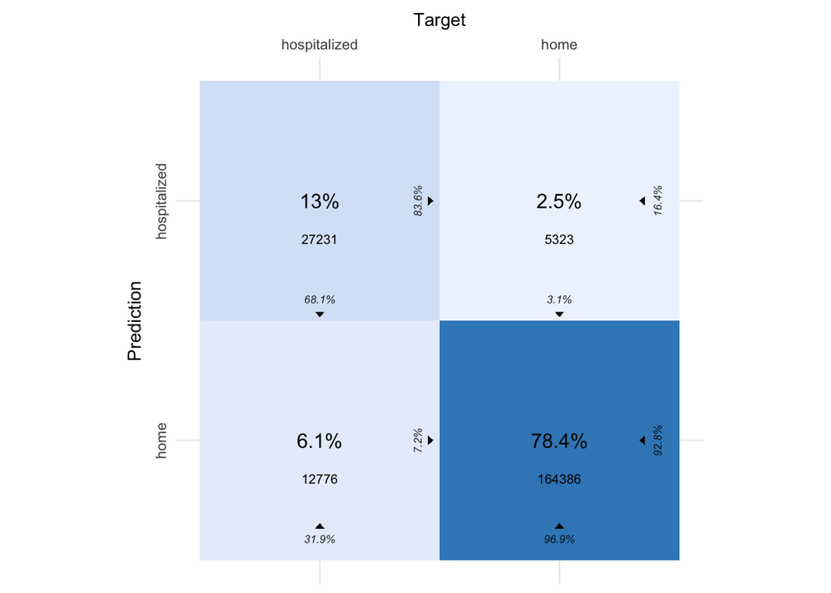

This decision tree model with minimum node size 2 and tree depth 4 performs well with our test data, with an accuracy of 91.4%. It is clear from the resulting confusion matrix that this model exhibits a larger error rate for predicting hospitalizations. Future analyses would aim to improve on this error rate, where 31.9% of hospitalizations are incorrectly predicted as sent home.

## Conclusions

Every model tested performed better than the null model on the training data (with ~ 80% accuracy). A Lasso logistic regression performed very similarly to our decision tree (91.4% accuracy) with an accuracy of 91.3% on the training set. Our decision tree won, however. Future attempts to improve on this predictive accuracy rate could come through exploration of K-nearest neighbors and other unsupervised analyses, as well as increasing the complexity of our cross-validation and model tuning.

## References

Data Source:

Nizri, M. (2022, November). *COVID-19 Dataset*. Retrieved March 2023, from https://www.kaggle.com/datasets/meirnizri/covid19-dataset?select=Covid+Data.csv.

Penalty Tuning Methodology:

Vaughan, D., Hfitfeldt, E., Frick, H., Silge, J., Michael Mahoney, & Kuhn, M. (2023). *Get started - A predictive modeling case study*. Kaggle.com. Retrieved March 2023, from https://www.tidymodels.org/start/case-study/#first-model